# Education and Unemployment Through the Pandemic and Recovery

U.S. adults ages 25–64, 2019–2024

Data Visz

labor market

R

Author

Michael Li

Published

September 27, 2026

The unemployment rate gives us a quick picture of the job market, but people with different levels of education may have very different experiences. I wanted to look more closely at those differences. **How did unemployment vary by education from 2019 to 2024, and does the latest comparison also hold within age groups?** I start with 2019 to see where each group stood before the pandemic. Then I look at the change in 2020 and the pattern through 2024. Finally, I compare education groups among people of similar ages. This helps separate a group’s starting unemployment rate from how much its situation changed. ## Data and approach For this post, I use [IPUMS CPS](https://cps.ipums.org/cps/) Basic Monthly data covering all 72 months from January 2019 through December 2024. I focus on civilians ages 25–64 who are in the labor force. Starting at 25 reduces the influence of people still finishing their initial education, while stopping at 64 limits differences related to retirement. I use four education groups: less than high school, high school or equivalent, some college or an associate’s degree, and a bachelor’s degree or more. The unemployment rate measures unemployed people, including those on temporary layoff, as a share of the labor force. People outside the labor force are left out of that calculation.

**Show the R code**

```r
library(tidyverse)
library(here)

post_dir <- here("blog", "posts", "post3")

data_file <- file.path(
  post_dir, "data", "cps_2019_2024.csv.gz"
)

results_dir <- file.path(post_dir, "results")

dir.create(
  results_dir,
  showWarnings = FALSE,
  recursive = TRUE
)

stopifnot(file.exists(data_file))

cps_raw <- read_csv(
  data_file,
  col_select = c(YEAR, MONTH, ASECFLAG, AGE, EDUC, EMPSTAT, WTFINL),
  col_types = cols(.default = col_double()),
  show_col_types = FALSE
)

stopifnot(nrow(problems(cps_raw)) == 0)
stopifnot(sum(cps_raw$ASECFLAG == 1, na.rm = TRUE) == 0)
#want to check every requested year and month is present.
cps_raw <- cps_raw |> filter(YEAR %in% 2019:2024)
month_check <- cps_raw |> distinct(YEAR, MONTH)
stopifnot(
  nrow(month_check) == 72,
  all(month_check$MONTH %in% 1:12)
)
education_order <- c(
  "Less than high school", "High school",
  "Some college / associate", "Bachelor's or more"
)
# keep those employed and unemployed adults
cps_eligible <- cps_raw |>
  filter(AGE >= 25, AGE <= 64, EMPSTAT %in% c(10, 12, 20, 21, 22))

cps <- cps_eligible |>
  mutate(
    education = case_when(
      EDUC >= 2 & EDUC <= 71 ~ "Less than high school",
      EDUC == 73 ~ "High school",
      EDUC %in% c(81, 91, 92) ~ "Some college / associate",
      EDUC %in% c(111, 123, 124, 125) ~ "Bachelor's or more",
      TRUE ~ NA_character_
    ),
    education = factor(education, levels = education_order),
    unemployed = EMPSTAT %in% c(20, 21, 22),
    age_group = case_when(
      AGE <= 34 ~ "25–34",
      AGE <= 44 ~ "35–44",
      AGE <= 54 ~ "45–54",
      TRUE ~ "55–64"
    )
  ) |>
  filter(!is.na(education), !is.na(WTFINL), is.finite(WTFINL), WTFINL > 0)
excluded_n <- nrow(cps_eligible) - nrow(cps)
#the formula for annual unemployment rate is: 100 x weighted unemployed / weighted labor force.
#Pooling all 12 months makes this a ratio of annual-average population totals.
annual <- cps |>
  group_by(YEAR, education) |>
  summarise(
    observations = n(),
    months = n_distinct(MONTH),
    unemployment_rate = 100 * sum(WTFINL * unemployed) / sum(WTFINL),
    .groups = "drop"
  )
#we require all four education groups in each year, with all 12 months.
stopifnot(
  nrow(annual) == 24,
  all(annual$months == 12),
  all(annual$unemployment_rate >= 0 & annual$unemployment_rate <= 100)
)
#Figure 2: use pivot_wider() to put 2019 and 2020 on the same row.
shock <- annual |>
  filter(YEAR %in% c(2019, 2020)) |>
  select(education, YEAR, unemployment_rate) |>
  pivot_wider(
    names_from = YEAR, values_from = unemployment_rate, names_prefix = "rate_"
  ) |>
  mutate(change_pp = rate_2020 - rate_2019)
#Figure 3: calculate the same weighted rate within four age groups in 2024.
by_age <- cps |>
  filter(YEAR == 2024) |>
  group_by(YEAR, age_group, education) |>
  summarise(
    observations = n(),
    months = n_distinct(MONTH),
    unemployment_rate = 100 * sum(WTFINL * unemployed) / sum(WTFINL),
    .groups = "drop"
  )
stopifnot(nrow(by_age) == 16, all(by_age$months == 12))
#stacks the three summary tables.
all_results <- bind_rows(
  annual |> mutate(result = "annual_rates"),
  shock |> mutate(result = "change_2019_2020"),
  by_age |> mutate(result = "age_rates_2024")
)
write_csv(all_results, file.path(results_dir, "summary_results.csv"))
#make the displayed numbers easier to read.
comparison <- annual |>
  select(YEAR, education, unemployment_rate) |>
  pivot_wider(names_from = education, values_from = unemployment_rate)
baseline <- comparison |> filter(YEAR == 2019)
latest <- comparison |> filter(YEAR == 2024)
hs_change <- shock$change_pp[shock$education == "High school"]
college_change <- shock$change_pp[shock$education == "Bachelor's or more"]
age_comparison <- by_age |>
  select(age_group, education, unemployment_rate) |>
  pivot_wider(names_from = education, values_from = unemployment_rate)
age_count <- sum(age_comparison$`High school` > age_comparison$`Bachelor's or more`)
change_description <- if_else(
  hs_change > college_change,
  "The high school group saw the larger change in its unemployment rate.",
  "The high school group's change was no larger than the college group's."
)
takeaway <- if_else(
  latest$`High school` > latest$`Bachelor's or more`,
  "In 2024, unemployment was lower among people with at least a bachelor's degree than among those whose highest qualification was high school.",
  "In 2024, having at least a bachelor's degree was not associated with a lower unemployment rate than having only a high school diploma."
)
#use the same source note and figure dimensions throughout the post.
source_note <- "Source: IPUMS CPS, University of Minnesota. Weighted using WTFINL."
knitr::opts_chunk$set(fig.width = 9, fig.height = 5.5, dpi = 150)
```

After cleaning, I have 2,992,422 person-month records. I leave out 0 otherwise eligible records because their education or weight cannot be used. The CPS interviews some people in several months, so the record count includes repeat interviews. Each respondent represents a different number of people. To account for that, I use the `WTFINL` weight recommended by [IPUMS](https://cps.ipums.org/cps-action/variables/WTFINL). For each group and year, I add up the weighted unemployed and divide by the weighted labor force, then multiply by 100. Pooling all 12 months gives the ratio of annual-average totals. I do not apply seasonal adjustment. ## 1. How did the education groups move over time?

**Show the R code**

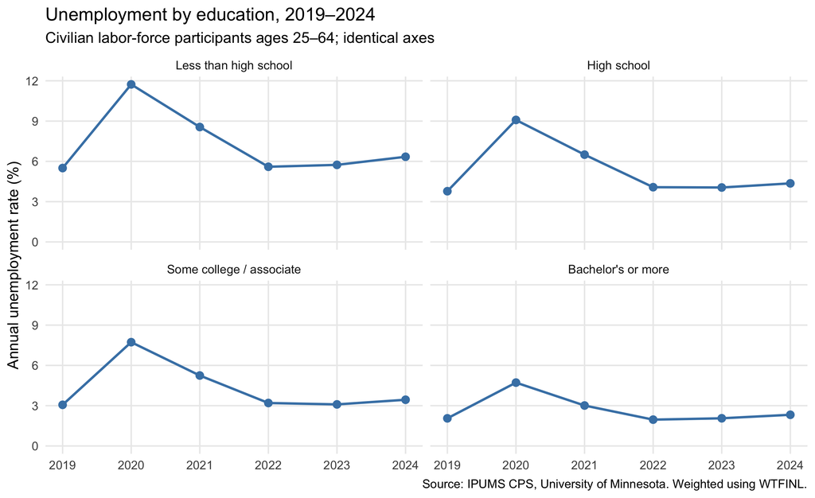

```r
figure1 <- ggplot(
  annual,
  aes(x = YEAR, y = unemployment_rate)
) +
  geom_line(linewidth = 0.9, color = "steelblue") +
  geom_point(size = 2.5, color = "steelblue") +
  facet_wrap(~ education, ncol = 2) +
  scale_x_continuous(breaks = 2019:2024) +
  scale_y_continuous(limits = c(0, NA)) +
  labs(
    title = "Unemployment by education, 2019–2024",
    subtitle = "Civilian labor-force participants ages 25–64; identical axes",
    x = NULL, y = "Annual unemployment rate (%)",
    caption = source_note
  ) +
  theme_minimal(base_size = 12) +
  theme(panel.grid.minor = element_blank())
figure1
```

**Show the R code**

```r
ggsave(file.path(results_dir, "figure1_trend.png"), figure1,
       width = 9, height = 5.5, dpi = 300)
```

I first look at the full six-year picture. In 2019, unemployment was 3.8% among people with only a high school diploma, compared with 2.1% among those with at least a bachelor’s degree. In 2024, those rates were 4.4% and 2.3%. Each panel uses the same scale, so we can compare both the levels and the paths over time. The next figure looks directly at how much each group changed in 2020. ## 2. How large was the change in 2020?

**Show the R code**

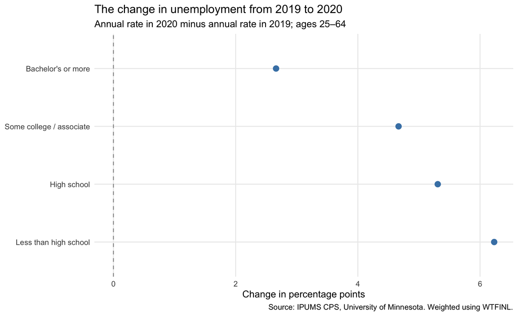

```r
figure2 <- ggplot(shock, aes(x = change_pp, y = education)) +
  geom_vline(xintercept = 0, linetype = "dashed", color = "grey60") +
  geom_point(size = 3, color = "steelblue") +
  labs(
    title = "The change in unemployment from 2019 to 2020",
    subtitle = "Annual rate in 2020 minus annual rate in 2019; ages 25–64",
    x = "Change in percentage points", y = NULL,
    caption = source_note
  ) +
  theme_minimal(base_size = 12) +
  theme(panel.grid.minor = element_blank())
figure2
```

**Show the R code**

```r
ggsave(file.path(results_dir, "figure2_change.png"), figure2,
       width = 9, height = 5.5, dpi = 300)
```

To make the 2020 change easier to compare, I subtract each group’s 2019 rate from its 2020 rate. The change was 5.3 percentage points for the high school group and 2.7 points for the bachelor’s-or-more group. The high school group saw the larger change in its unemployment rate. For context, going from 4% to 7% would be a three-percentage-point increase. These changes describe the groups’ unemployment rates; they do not track which individual workers lost jobs. ## 3. Does the latest comparison hold within age groups?

**Show the R code**

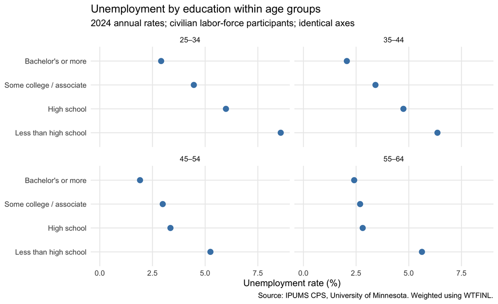

```r
figure3 <- ggplot(by_age, aes(x = unemployment_rate, y = education)) +
  geom_point(size = 3, color = "steelblue") +
  facet_wrap(~ age_group, ncol = 2) +
  scale_x_continuous(limits = c(0, NA)) +
  labs(
    title = "Unemployment by education within age groups",
    subtitle = "2024 annual rates; civilian labor-force participants; identical axes",
    x = "Unemployment rate (%)", y = NULL,
    caption = source_note
  ) +
  theme_minimal(base_size = 12) +
  theme(panel.grid.minor = element_blank())
figure3
```

**Show the R code**

```r
ggsave(file.path(results_dir, "figure3_age.png"), figure3,
       width = 9, height = 7, dpi = 300)
```

I also wanted to check whether the overall comparison holds among people of similar ages. In 2024, the high school group had higher unemployment than the bachelor’s-or-more group in 4 of the four age groups. Breaking the results down this way shows where the overall pattern holds and where it does not. People within an age group can still have different backgrounds and jobs, so this does not remove every possible explanation for the gap.

What stands out to me is how much the high-school–bachelor’s gap differs by age. Among adults ages 25–34, unemployment was 6.0% for the high school group and 2.9% for the bachelor’s-or-more group, a gap of 3.1 percentage points. Among those ages 55–64, the rates were 2.8% and 2.4%, leaving a gap of only 0.4 points. This helps explain why the age breakdown matters: the overall comparison holds among people of similar ages, but the difference between these two education groups is much wider among younger adults. ## How I read these results I would be careful about saying education alone caused these differences. People with different qualifications also work in different occupations, industries, and places. The analysis leaves out people outside the labor force, and [IPUMS reports pandemic-era nonresponse and employment-status misclassification](https://cps.ipums.org/cps/covid19.shtml). I keep the reported classifications. I also do not calculate confidence intervals that account for the survey design, so I would not read too much into small gaps. **My takeaway:** In 2024, unemployment was lower among people with at least a bachelor’s degree than among those whose highest qualification was high school. Looking at the trend, the change in 2020, and the age groups gives a fuller picture of how unemployment differed across education levels. These comparisons help describe who was struggling in the job market, while leaving open the question of how much of the difference education itself explains.

The age results also help me be more specific about that takeaway. The high-school–bachelor’s gap appears in every age group, but it is largest at ages 25–34 and smallest at ages 55–64. I would therefore be cautious about using the overall average to describe the gap at every age. This is a comparison of different groups in 2024, so it does not show that the value of education declines as an individual gets older. Data source: [IPUMS CPS, University of Minnesota](https://cps.ipums.org/cps/citation.shtml). Variable definitions: EDUC, EMPSTAT, and WTFINL. All analysis code appears in this post; the repository README provides replication instructions.